# Adherence to Interventions

Exploratory summaries of intervention adherence.

Author

James Totterdell

Published

July 26, 2023

# Withdrawals

```
# A tibble: 3 × 3
  WTH_FU WTH_rec     n
   <int>   <dbl> <int>
1      0       0   140
2      0       1    15
3      1       1     3
```

```
# A tibble: 18 × 11
   StudyPatientID AAssignment WTH_FU CON_WithdrawnContact28 CON_WithdrawalReason
   <chr>          <chr>        <int> <chr>                  <chr>
 1 RPH00005       A1               0 No                     Primary treating cl…
 2 WES00058       A1               0 No                     Consent withdrawn
 3 WWB00008       A1               0 No                     Consent withdrawn
 4 ALF00008       A2               0 No                     Consent withdrawn
 5 ALF00009       A2               0 No                     Other
 6 ALF00013       A2               0 No                     Primary treating cl…
 7 ALF00014       A2               0 No                     Primary treating cl…
 8 LIV00018       A2               0 No                     Consent withdrawn
 9 MMC00079       A2               0 No                     Primary treating cl…
10 PRC00009       A2               0 No                     Primary treating cl…
11 RMH00022       A2               1 Yes                    Consent withdrawn
12 RMH00026       A2               0 No                     Consent withdrawn
13 RPH00004       A2               0 No                     Consent withdrawn
14 WES00022       A2               0 No                     Primary treating cl…
15 WES00040       A2               1 Yes                    Consent withdrawn
16 WES00041       A2               1 Yes                    Other
17 WES00060       A2               0 No                     Consent withdrawn
18 WSH00013       A2               0 No                     Consent withdrawn
# ℹ 6 more variables: CON_WithdrawnDomainA <chr>,
#   `CON_WithdrawnDate - RandDate` <drtn>, DD_total_days <dbl>,
#   `Per Protocol?` <chr>, reason <chr>, pp <dbl>
```

```
# A tibble: 15 × 11
   StudyPatientID AAssignment WTH_FU CON_WithdrawnContact28 CON_WithdrawalReason
   <chr>          <chr>        <int> <chr>                  <chr>
 1 ALF00008       A2               0 No                     Consent withdrawn
 2 ALF00009       A2               0 No                     Other
 3 ALF00013       A2               0 No                     Primary treating cl…
 4 ALF00014       A2               0 No                     Primary treating cl…
 5 LIV00018       A2               0 No                     Consent withdrawn
 6 MMC00079       A2               0 No                     Primary treating cl…
 7 PRC00009       A2               0 No                     Primary treating cl…
 8 RMH00022       A2               1 Yes                    Consent withdrawn
 9 RMH00026       A2               0 No                     Consent withdrawn
10 RPH00004       A2               0 No                     Consent withdrawn
11 WES00022       A2               0 No                     Primary treating cl…
12 WES00040       A2               1 Yes                    Consent withdrawn
13 WES00041       A2               1 Yes                    Other
14 WES00060       A2               0 No                     Consent withdrawn
15 WSH00013       A2               0 No                     Consent withdrawn
# ℹ 6 more variables: CON_WithdrawnDomainA <chr>,
#   `CON_WithdrawnDate - RandDate` <drtn>, DD_total_days <dbl>,
#   `Per Protocol?` <chr>, reason <chr>, pp <dbl>
```

```
# A tibble: 13 × 5
      pp WTH_rec CON_WithdrawalReason       reason                             n
   <dbl>   <dbl> <chr>                      <chr>                          <int>
 1     0       0 <NA>                       >3 hr disruption                   8
 2     0       0 <NA>                       >3 hr disruption. Dose was ch…     1
 3     0       0 <NA>                       Patient received more than al…     1
 4     0       1 Consent withdrawn          withdrawn after baseline from…     1
 5     0       1 Consent withdrawn          withdrawn from antiviral trea…     6
 6     0       1 Consent withdrawn          withdrew after baseline from …     1
 7     0       1 Other                      withdrawn after baseline from…     1
 8     0       1 Other                      withdrawn from antiviral trea…     1
 9     0       1 Primary treating clinician >3 hr disruption                   1
10     0       1 Primary treating clinician withdrawn from antiviral trea…     1
11     1       0 <NA>                       <NA>                              60
12     1       1 Primary treating clinician withdrawn from antiviral & an…     1
13     1       1 Primary treating clinician <NA>                               2
```

```
# A tibble: 6 × 4
  CON_WithdrawalReason       CON_WithdrawnContact28 CON_WithdrawnDomainA      n
  <chr>                      <chr>                  <chr>                 <int>
1 Consent withdrawn          No                     Withdrawn                 8
2 Consent withdrawn          Yes                    Withdrawn                 2
3 Other                      No                     Withdrawn                 1
4 Other                      Yes                    Withdrawn                 1
5 Primary treating clinician No                     Continue with consent     1
6 Primary treating clinician No                     Withdrawn                 5
```

# Nafamostat

## Dosage

Per the protocol:

> Nafamostat is administered by constant intravenous infusion at a fixed dose based on total body weight as per Table below, for 7 days, or until hospital discharge, whichever is sooner. This dosing table is based on a dose of 0.2mg/kg/hr.

| Body Weight (kg) | Daily Dose (mg/day) |
| --- | --- |
| < 40 | 200 |
| 40 - 60 | 250 |
| 61 - 80 | 350 |
| 81 - 100 | 450 |
| > 100 | 500 |

## Fields

The relevant fields are:

- `DD_NafamostatAdministered` - Was nafamostat administered
- `DD_NafamostatDailyDose` - Total daily dose prescribed per 24 hours (mg/day)
- `DD_NafamostatDuration` - Total cumulative duration of nafamostat infusion on this calendar day (hours)

A list of per protocol participants was provided

```
# A tibble: 2 × 2
  `Per Protocol?`      n
  <chr>            <int>
1 Not Per Protocol    24
2 Per Protocol       135
```

```
# A tibble: 11 × 3
   `Per Protocol?`  reason                                                     n
   <chr>            <chr>                                                  <int>
 1 Not Per Protocol >3 hr disruption                                           9
 2 Not Per Protocol >3 hr disruption. Dose was charted incorrectly for pa…     1
 3 Not Per Protocol Patient received more than allocated dose (up to day …     1
 4 Not Per Protocol excluded from analysis                                     1
 5 Not Per Protocol withdrawn after baseline from antiviral treatment and…     2
 6 Not Per Protocol withdrawn from antiviral & anticoagulation treatment …     1
 7 Not Per Protocol withdrawn from antiviral treatment (by patient)            7
 8 Not Per Protocol withdrawn from antiviral treatment (by treating clini…     1
 9 Not Per Protocol withdrew after baseline from all aspects (by patient)      1
10 Per Protocol     withdrawn from antiviral & anticoagulation treatment …     1
11 Per Protocol     <NA>                                                     134
```

Of particular note

```
# A tibble: 1 × 4
  StudyPatientID `Per Protocol?`  reason                    pp
  <chr>          <chr>            <chr>                  <dbl>
1 BLK00001       Not Per Protocol excluded from analysis     0
```

> BLK00001 – Previously available data recorded in Baseline and Daily CRFs were deleted from the database and no longer appear in data exports, due to a serious breach related to consent. This patient was ineligible for the trial. For the purpose of analysis, please do not include the clinical data collected during screening for this patient. MMC00081 – This participant was enrolled in the anticoagulation domain and data collected for that domain was included in the anticoagulation domain analysis. They were enrolled but did not consent to participate in the Antiviral Domain (serious breach). The participant was randomised to the Standard Of Care arm in the Antiviral domain therefore they did not receive any interventions. All data specific to the antiviral domain must be redacted for this participant when analysing the datasets.

We note that BLK00001 is excluded from all analysis sets and MMC00081 antiviral data was set to missing.

```
# A tibble: 4 × 3
  AAssignment    pp     n
  <chr>       <dbl> <int>
1 A1              0     1
2 A1              1    72
3 A2              0    19
4 A2              1    63
```

## Not Per-Protocol

```
# A tibble: 20 × 16
   StudyPatientID RandomisedLocal     AAssignment BAS_Weight DIS_day reason
   <chr>          <dttm>              <chr>            <dbl>   <dbl> <chr>
 1 ALF00008       2021-10-04 15:51:00 A2                 107       4 withdrawn …
 2 ALF00009       2021-10-06 16:15:00 A2                  78       4 withdrawn …
 3 ALF00013       2021-10-15 14:25:00 A2                  70      11 withdrawn …
 4 ALF00015       2022-02-14 11:52:00 A2                  88      10 Patient re…
 5 BXH00081       2021-10-22 12:46:00 A2                 109       8 >3 hr disr…
 6 LIV00018       2021-09-24 12:11:00 A2                 135       5 withdrawn …
 7 MID00009       2021-09-20 14:37:00 A2                 190       8 >3 hr disr…
 8 MID00011       2021-09-30 15:32:00 A2                 145      15 >3 hr disr…
 9 MMC00077       2021-11-12 13:44:00 A2                 121       5 >3 hr disr…
10 MMC00078       2021-11-12 17:40:00 A2                  65       8 >3 hr disr…
11 MMC00079       2021-11-15 12:58:00 A2                  97      22 >3 hr disr…
12 RMH00026       2021-09-01 12:06:00 A2                  91       6 withdrawn …
13 RNS00006       2021-09-10 16:04:00 A2                 105       6 >3 hr disr…
14 RPH00004       2022-03-15 11:42:00 A2                  79       2 withdrawn …
15 WES00037       2021-08-23 15:53:00 A2                  70       9 >3 hr disr…
16 WES00048       2021-09-22 10:02:00 A2                 160      11 >3 hr disr…
17 WES00058       2021-12-07 11:07:00 A1                  92       6 withdrawn …
18 WES00060       2022-01-28 08:12:00 A2                  90     106 withdrawn …
19 WSH00013       2021-10-29 16:25:00 A2                  95       6 withdrawn …
20 WWB00003       2021-11-08 12:13:00 A2                 111      20 >3 hr disr…
# ℹ 10 more variables: pp <dbl>, expect_dose <dbl>, `1` <dbl>, `2` <dbl>,
#   `3` <dbl>, `4` <dbl>, `5` <dbl>, `6` <dbl>, `7` <dbl>, `8` <dbl>
```

## Per Protocol

```
# A tibble: 63 × 15
   StudyPatientID RandomisedLocal     AAssignment BAS_Weight DIS_day    pp
   <chr>          <dttm>              <chr>            <dbl>   <dbl> <dbl>
 1 ALF00003       2021-09-06 12:09:00 A2                  78       7     1
 2 ALF00004       2021-09-14 11:12:00 A2                  81       4     1
 3 ALF00007       2021-10-04 12:18:00 A2                 125       4     1
 4 ALF00010       2021-10-13 16:05:00 A2                  79       5     1
 5 ALF00012       2021-10-14 16:20:00 A2                 110       4     1
 6 ALF00014       2021-10-27 15:21:00 A2                  91       8     1
 7 BHN00085       2022-07-19 06:43:00 A2                  60       4     1
 8 CAM00001       2021-09-03 13:54:00 A2                 148       5     1
 9 CAM00002       2021-09-16 15:42:00 A2                  89      10     1
10 CAM00005       2021-09-24 12:27:00 A2                  84       4     1
11 CAM00006       2021-09-28 17:19:00 A2                 110       4     1
12 CAM00007       2021-10-05 12:59:00 A2                  93       4     1
```

[output cut: 53 more lines]

| Antiviral | Per Protocol? | Reason | Count |
| --- | --- | --- | --- |
| Standard of care | Not Per Protocol | withdrawn from antiviral & anticoagulation treatment (by patient) | 1 |
| Standard of care | Per Protocol | NA | 72 |
| Nafamostat | Not Per Protocol | >3 hr disruption | 9 |
| Nafamostat | Not Per Protocol | withdrawn from antiviral treatment (by patient) | 7 |
| Nafamostat | Not Per Protocol | >3 hr disruption. Dose was charted incorrectly for patient's weight on days 1 to 4. | 1 |
| Nafamostat | Not Per Protocol | Patient received more than allocated dose (up to day 9) with a disruption on day 7 of >3hrs | 1 |
| Nafamostat | Not Per Protocol | withdrawn from antiviral treatment (by treating clinician due to nausea and vomitting) | 1 |
| Nafamostat | Per Protocol | NA | 62 |
| Nafamostat | Per Protocol | withdrawn from antiviral & anticoagulation treatment (by treating clinician due to concerns about haemoptysis) | 1 |

## Study Day Summaries

```
# A tibble: 8 × 6
  DD_StudyDay     n n_administered p_administered mean_duration median_duration
        <dbl> <int>          <int>          <dbl>         <dbl>           <dbl>
1           1    82             77          0.939          6.75               7
2           2    82             80          0.976         21.9               24
3           3    79             73          0.924         21.4               24
4           4    72             60          0.833         18.4               24
5           5    55             45          0.818         17.1               24
6           6    43             33          0.767         16.8               24
7           7    35             26          0.743         15.4               20
8           8    29             15          0.517          8.45              10
```

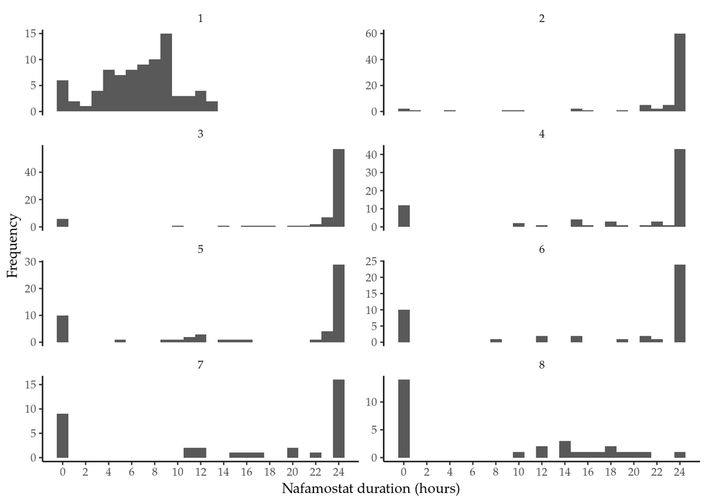

## Patient Summaries

```
# A tibble: 17 × 15
   StudyPatientID DD_NafamostatDailyDose.x expect_dose.x RandomisedLocal
   <chr>                             <dbl>         <dbl> <dttm>
 1 MMC00078                            500           350 2021-11-12 17:40:00
 2 MMC00078                            500           350 2021-11-12 17:40:00
 3 MMC00078                            500           350 2021-11-12 17:40:00
 4 MMC00078                            500           350 2021-11-12 17:40:00
 5 MMC00078                            500           350 2021-11-12 17:40:00
 6 MMC00078                            500           350 2021-11-12 17:40:00
 7 MMC00078                            500           350 2021-11-12 17:40:00
 8 MMC00078                            500           350 2021-11-12 17:40:00
 9 WWB00002                            350           250 2021-11-02 12:22:00
10 WWB00002                            350           250 2021-11-02 12:22:00
11 WWB00002                            350           250 2021-11-02 12:22:00
12 WWB00002                            350           250 2021-11-02 12:22:00
13 WWB00002                            350           250 2021-11-02 12:22:00
14 WWB00002                            350           250 2021-11-02 12:22:00
15 WWB00002                            350           250 2021-11-02 12:22:00
16 WWB00002                            350           250 2021-11-02 12:22:00
17 WWB00002                            350           250 2021-11-02 12:22:00
# ℹ 11 more variables: AAssignment <chr>, BAS_Weight <dbl>, DIS_day <dbl>,
#   DD_StudyDay <dbl>, DD_NafamostatDailyDose.y <dbl>,
#   DD_NafamostatAdministered <chr>, DD_NafamostatDuration <dbl>,
#   `Per Protocol?` <chr>, reason <chr>, pp <dbl>, expect_dose.y <dbl>
```

| Summary | Value |
| --- | --- |
| **Days on study treatment** |  |
| Median (IQR) | 5 (3 - 7) |
| Min, Max | 0, 8 |
| Missing | 0 |
| **Days off study treatment** |  |
| Median (IQR) | 0 (0 - 1) |
| Min, Max | 0, 7 |
| Missing | 0 |
| **Total hours receiving infusion** |  |
| Median (IQR) | 89.7 (57.8 - 138.8) |
| Min, Max | 0.0, 176.6 |
| Missing | 0 |
| **Hours per day on infusion** |  |
| Median (IQR) | 17.6 (14.3 - 19.7) |
| Min, Max | 0.0, 22.1 |
| Missing | 0 |
| **Proportion of days admitted to hospital with infusion $\geq$ 21/24 hours$^1$ (day 2 to 8 or before discharge)** |  |
| Median (IQR) | 1.00 (0.72 - 1.00) |
| Min, Max | 0.00, 1.00 |
| Missing | 0 |
| **Proportion of days admitted to hospital with infusion $\geq$ 21/24 hours$^1$ (day 2 to 7 or before discharge)** |  |
| Median (IQR) | 1.00 (0.83 - 1.00) |
| Min, Max | 0.00, 1.00 |
| Missing | 0 |
| **Days with 21/24 hours infusion** |  |
| Median (IQR) | 3 (2 - 5) |
| Min, Max | 0, 7 |
| Missing | 0 |
| **Days without 21/24 hours infusion** |  |
| Median (IQR) | 0 (0 - 1) |
| Min, Max | 0, 6 |
| Missing | 0 |

Days on study treatment is any part day on drug.  
Days off treatment is any day when no Nafamostat was administered.  
Days without 21/24 excludes day 1 and day of discharge.  
<sup>1</sup> up to 7 days while hospitalised